# Risk Factor Analysis

## Outcome Variable

**Outcome Variable:** ever_wasted

## Predictor Variables

**Intervention Variable:** perdiar24

**Adjustment Set:**

unadjusted

## Stratifying Variables

The analysis was stratified on these variable(s):

- agecat
- studyid
- country

## Data Summary

| agecat | studyid | country | perdiar24 | ever_wasted | n_cell | n |
| --- | --- | --- | --- | --- | --- | --- |
| 0-24 months (no birth wast) | ki0047075b-MAL-ED | BANGLADESH | (0%, 5%] | 0 | 112 | 263 |
| 0-24 months (no birth wast) | ki0047075b-MAL-ED | BANGLADESH | (0%, 5%] | 1 | 36 | 263 |
| 0-24 months (no birth wast) | ki0047075b-MAL-ED | BANGLADESH | >5% | 0 | 76 | 263 |
| 0-24 months (no birth wast) | ki0047075b-MAL-ED | BANGLADESH | >5% | 1 | 19 | 263 |
| 0-24 months (no birth wast) | ki0047075b-MAL-ED | BANGLADESH | 0% | 0 | 17 | 263 |
| 0-24 months (no birth wast) | ki0047075b-MAL-ED | BANGLADESH | 0% | 1 | 3 | 263 |
| 0-24 months (no birth wast) | ki0047075b-MAL-ED | BRAZIL | (0%, 5%] | 0 | 95 | 232 |
| 0-24 months (no birth wast) | ki0047075b-MAL-ED | BRAZIL | (0%, 5%] | 1 | 5 | 232 |
| 0-24 months (no birth wast) | ki0047075b-MAL-ED | BRAZIL | >5% | 0 | 1 | 232 |
| 0-24 months (no birth wast) | ki0047075b-MAL-ED | BRAZIL | >5% | 1 | 1 | 232 |
| 0-24 months (no birth wast) | ki0047075b-MAL-ED | BRAZIL | 0% | 0 | 124 | 232 |
| 0-24 months (no birth wast) | ki0047075b-MAL-ED | BRAZIL | 0% | 1 | 6 | 232 |
| 0-24 months (no birth wast) | ki0047075b-MAL-ED | INDIA | (0%, 5%] | 0 | 118 | 246 |
| 0-24 months (no birth wast) | ki0047075b-MAL-ED | INDIA | (0%, 5%] | 1 | 73 | 246 |
| 0-24 months (no birth wast) | ki0047075b-MAL-ED | INDIA | >5% | 0 | 27 | 246 |
| 0-24 months (no birth wast) | ki0047075b-MAL-ED | INDIA | >5% | 1 | 15 | 246 |
| 0-24 months (no birth wast) | ki0047075b-MAL-ED | INDIA | 0% | 0 | 12 | 246 |
| 0-24 months (no birth wast) | ki0047075b-MAL-ED | INDIA | 0% | 1 | 1 | 246 |
| 0-24 months (no birth wast) | ki0047075b-MAL-ED | NEPAL | (0%, 5%] | 0 | 113 | 239 |
| 0-24 months (no birth wast) | ki0047075b-MAL-ED | NEPAL | (0%, 5%] | 1 | 30 | 239 |
| 0-24 months (no birth wast) | ki0047075b-MAL-ED | NEPAL | >5% | 0 | 65 | 239 |
| 0-24 months (no birth wast) | ki0047075b-MAL-ED | NEPAL | >5% | 1 | 14 | 239 |
| 0-24 months (no birth wast) | ki0047075b-MAL-ED | NEPAL | 0% | 0 | 16 | 239 |
| 0-24 months (no birth wast) | ki0047075b-MAL-ED | NEPAL | 0% | 1 | 1 | 239 |
| 0-24 months (no birth wast) | ki0047075b-MAL-ED | PERU | (0%, 5%] | 0 | 106 | 302 |
| 0-24 months (no birth wast) | ki0047075b-MAL-ED | PERU | (0%, 5%] | 1 | 7 | 302 |
| 0-24 months (no birth wast) | ki0047075b-MAL-ED | PERU | >5% | 0 | 148 | 302 |
| 0-24 months (no birth wast) | ki0047075b-MAL-ED | PERU | >5% | 1 | 13 | 302 |
| 0-24 months (no birth wast) | ki0047075b-MAL-ED | PERU | 0% | 0 | 28 | 302 |
| 0-24 months (no birth wast) | ki0047075b-MAL-ED | PERU | 0% | 1 | 0 | 302 |

[output cut: 342 more lines]

The following strata were considered:

- agecat: 0-24 months (no birth wast), studyid: ki0047075b-MAL-ED, country: BANGLADESH
- agecat: 0-24 months (no birth wast), studyid: ki0047075b-MAL-ED, country: BRAZIL
- agecat: 0-24 months (no birth wast), studyid: ki0047075b-MAL-ED, country: INDIA
- agecat: 0-24 months (no birth wast), studyid: ki0047075b-MAL-ED, country: NEPAL
- agecat: 0-24 months (no birth wast), studyid: ki0047075b-MAL-ED, country: PERU
- agecat: 0-24 months (no birth wast), studyid: ki0047075b-MAL-ED, country: SOUTH AFRICA
- agecat: 0-24 months (no birth wast), studyid: ki0047075b-MAL-ED, country: TANZANIA, UNITED REPUBLIC OF
- agecat: 0-24 months (no birth wast), studyid: ki1000109-EE, country: PAKISTAN
- agecat: 0-24 months (no birth wast), studyid: ki1000109-ResPak, country: PAKISTAN
- agecat: 0-24 months (no birth wast), studyid: ki1000304b-SAS-FoodSuppl, country: INDIA
- agecat: 0-24 months (no birth wast), studyid: ki1017093-NIH-Birth, country: BANGLADESH
- agecat: 0-24 months (no birth wast), studyid: ki1017093b-PROVIDE, country: BANGLADESH
- agecat: 0-24 months (no birth wast), studyid: ki1017093c-NIH-Crypto, country: BANGLADESH
- agecat: 0-24 months (no birth wast), studyid: ki1112895-Guatemala BSC, country: GUATEMALA
- agecat: 0-24 months (no birth wast), studyid: ki1112895-iLiNS-Zinc, country: BURKINA FASO
- agecat: 0-24 months (no birth wast), studyid: ki1114097-CMIN, country: BANGLADESH
- agecat: 0-24 months (no birth wast), studyid: ki1114097-CMIN, country: BRAZIL
- agecat: 0-24 months (no birth wast), studyid: ki1114097-CMIN, country: GUINEA-BISSAU
- agecat: 0-24 months (no birth wast), studyid: ki1114097-CMIN, country: PERU
- agecat: 0-24 months (no birth wast), studyid: ki1114097-CONTENT, country: PERU
- agecat: 0-24 months (no birth wast), studyid: kiGH5241-JiVitA-4, country: BANGLADESH
- agecat: 0-6 months (no birth wast), studyid: ki0047075b-MAL-ED, country: BANGLADESH
- agecat: 0-6 months (no birth wast), studyid: ki0047075b-MAL-ED, country: BRAZIL
- agecat: 0-6 months (no birth wast), studyid: ki0047075b-MAL-ED, country: INDIA
- agecat: 0-6 months (no birth wast), studyid: ki0047075b-MAL-ED, country: NEPAL
- agecat: 0-6 months (no birth wast), studyid: ki0047075b-MAL-ED, country: PERU
- agecat: 0-6 months (no birth wast), studyid: ki0047075b-MAL-ED, country: SOUTH AFRICA
- agecat: 0-6 months (no birth wast), studyid: ki0047075b-MAL-ED, country: TANZANIA, UNITED REPUBLIC OF
- agecat: 0-6 months (no birth wast), studyid: ki1000109-EE, country: PAKISTAN
- agecat: 0-6 months (no birth wast), studyid: ki1000109-ResPak, country: PAKISTAN
- agecat: 0-6 months (no birth wast), studyid: ki1000304b-SAS-FoodSuppl, country: INDIA
- agecat: 0-6 months (no birth wast), studyid: ki1017093-NIH-Birth, country: BANGLADESH
- agecat: 0-6 months (no birth wast), studyid: ki1017093b-PROVIDE, country: BANGLADESH
- agecat: 0-6 months (no birth wast), studyid: ki1017093c-NIH-Crypto, country: BANGLADESH
- agecat: 0-6 months (no birth wast), studyid: ki1112895-Guatemala BSC, country: GUATEMALA
- agecat: 0-6 months (no birth wast), studyid: ki1114097-CMIN, country: BANGLADESH
- agecat: 0-6 months (no birth wast), studyid: ki1114097-CMIN, country: BRAZIL
- agecat: 0-6 months (no birth wast), studyid: ki1114097-CMIN, country: GUINEA-BISSAU
- agecat: 0-6 months (no birth wast), studyid: ki1114097-CMIN, country: PERU
- agecat: 0-6 months (no birth wast), studyid: ki1114097-CONTENT, country: PERU
- agecat: 0-6 months (no birth wast), studyid: kiGH5241-JiVitA-4, country: BANGLADESH
- agecat: 6-24 months, studyid: ki0047075b-MAL-ED, country: BANGLADESH
- agecat: 6-24 months, studyid: ki0047075b-MAL-ED, country: BRAZIL
- agecat: 6-24 months, studyid: ki0047075b-MAL-ED, country: INDIA
- agecat: 6-24 months, studyid: ki0047075b-MAL-ED, country: NEPAL
- agecat: 6-24 months, studyid: ki0047075b-MAL-ED, country: PERU
- agecat: 6-24 months, studyid: ki0047075b-MAL-ED, country: SOUTH AFRICA
- agecat: 6-24 months, studyid: ki0047075b-MAL-ED, country: TANZANIA, UNITED REPUBLIC OF
- agecat: 6-24 months, studyid: ki1000109-EE, country: PAKISTAN
- agecat: 6-24 months, studyid: ki1000109-ResPak, country: PAKISTAN
- agecat: 6-24 months, studyid: ki1000304b-SAS-FoodSuppl, country: INDIA
- agecat: 6-24 months, studyid: ki1017093-NIH-Birth, country: BANGLADESH
- agecat: 6-24 months, studyid: ki1017093b-PROVIDE, country: BANGLADESH
- agecat: 6-24 months, studyid: ki1017093c-NIH-Crypto, country: BANGLADESH
- agecat: 6-24 months, studyid: ki1112895-Guatemala BSC, country: GUATEMALA
- agecat: 6-24 months, studyid: ki1112895-iLiNS-Zinc, country: BURKINA FASO
- agecat: 6-24 months, studyid: ki1114097-CMIN, country: BANGLADESH
- agecat: 6-24 months, studyid: ki1114097-CMIN, country: BRAZIL
- agecat: 6-24 months, studyid: ki1114097-CMIN, country: GUINEA-BISSAU
- agecat: 6-24 months, studyid: ki1114097-CMIN, country: PERU
- agecat: 6-24 months, studyid: ki1114097-CONTENT, country: PERU
- agecat: 6-24 months, studyid: kiGH5241-JiVitA-4, country: BANGLADESH

### Dropped Strata

Some strata were dropped due to rare outcomes:

- agecat: 0-24 months (no birth wast), studyid: ki0047075b-MAL-ED, country: BANGLADESH
- agecat: 0-24 months (no birth wast), studyid: ki0047075b-MAL-ED, country: BRAZIL
- agecat: 0-24 months (no birth wast), studyid: ki0047075b-MAL-ED, country: INDIA
- agecat: 0-24 months (no birth wast), studyid: ki0047075b-MAL-ED, country: NEPAL
- agecat: 0-24 months (no birth wast), studyid: ki0047075b-MAL-ED, country: PERU
- agecat: 0-24 months (no birth wast), studyid: ki0047075b-MAL-ED, country: SOUTH AFRICA
- agecat: 0-24 months (no birth wast), studyid: ki0047075b-MAL-ED, country: TANZANIA, UNITED REPUBLIC OF
- agecat: 0-24 months (no birth wast), studyid: ki1017093-NIH-Birth, country: BANGLADESH
- agecat: 0-24 months (no birth wast), studyid: ki1017093b-PROVIDE, country: BANGLADESH
- agecat: 0-24 months (no birth wast), studyid: ki1112895-Guatemala BSC, country: GUATEMALA
- agecat: 0-24 months (no birth wast), studyid: ki1114097-CMIN, country: BANGLADESH
- agecat: 0-24 months (no birth wast), studyid: ki1114097-CMIN, country: BRAZIL
- agecat: 0-24 months (no birth wast), studyid: ki1114097-CMIN, country: PERU
- agecat: 0-24 months (no birth wast), studyid: ki1114097-CONTENT, country: PERU
- agecat: 0-6 months (no birth wast), studyid: ki0047075b-MAL-ED, country: BANGLADESH
- agecat: 0-6 months (no birth wast), studyid: ki0047075b-MAL-ED, country: BRAZIL
- agecat: 0-6 months (no birth wast), studyid: ki0047075b-MAL-ED, country: INDIA
- agecat: 0-6 months (no birth wast), studyid: ki0047075b-MAL-ED, country: NEPAL
- agecat: 0-6 months (no birth wast), studyid: ki0047075b-MAL-ED, country: PERU
- agecat: 0-6 months (no birth wast), studyid: ki0047075b-MAL-ED, country: SOUTH AFRICA
- agecat: 0-6 months (no birth wast), studyid: ki0047075b-MAL-ED, country: TANZANIA, UNITED REPUBLIC OF
- agecat: 0-6 months (no birth wast), studyid: ki1000304b-SAS-FoodSuppl, country: INDIA
- agecat: 0-6 months (no birth wast), studyid: ki1017093-NIH-Birth, country: BANGLADESH
- agecat: 0-6 months (no birth wast), studyid: ki1017093b-PROVIDE, country: BANGLADESH
- agecat: 0-6 months (no birth wast), studyid: ki1017093c-NIH-Crypto, country: BANGLADESH
- agecat: 0-6 months (no birth wast), studyid: ki1112895-Guatemala BSC, country: GUATEMALA
- agecat: 0-6 months (no birth wast), studyid: ki1114097-CMIN, country: BANGLADESH
- agecat: 0-6 months (no birth wast), studyid: ki1114097-CMIN, country: BRAZIL
- agecat: 0-6 months (no birth wast), studyid: ki1114097-CMIN, country: GUINEA-BISSAU
- agecat: 0-6 months (no birth wast), studyid: ki1114097-CMIN, country: PERU
- agecat: 0-6 months (no birth wast), studyid: ki1114097-CONTENT, country: PERU
- agecat: 6-24 months, studyid: ki0047075b-MAL-ED, country: BANGLADESH
- agecat: 6-24 months, studyid: ki0047075b-MAL-ED, country: BRAZIL
- agecat: 6-24 months, studyid: ki0047075b-MAL-ED, country: INDIA
- agecat: 6-24 months, studyid: ki0047075b-MAL-ED, country: NEPAL
- agecat: 6-24 months, studyid: ki0047075b-MAL-ED, country: PERU
- agecat: 6-24 months, studyid: ki0047075b-MAL-ED, country: SOUTH AFRICA
- agecat: 6-24 months, studyid: ki0047075b-MAL-ED, country: TANZANIA, UNITED REPUBLIC OF
- agecat: 6-24 months, studyid: ki1000109-ResPak, country: PAKISTAN
- agecat: 6-24 months, studyid: ki1017093-NIH-Birth, country: BANGLADESH
- agecat: 6-24 months, studyid: ki1017093b-PROVIDE, country: BANGLADESH
- agecat: 6-24 months, studyid: ki1112895-Guatemala BSC, country: GUATEMALA
- agecat: 6-24 months, studyid: ki1114097-CMIN, country: BANGLADESH
- agecat: 6-24 months, studyid: ki1114097-CMIN, country: BRAZIL
- agecat: 6-24 months, studyid: ki1114097-CMIN, country: PERU
- agecat: 6-24 months, studyid: ki1114097-CONTENT, country: PERU

## Methods Detail

We’re interested in the causal parameters $E[Y_a]$ for all values of $a \in \mathcal{A}$. These parameters represent the mean outcome if, possibly contrary to fact, we intervened to set all units to have $A=a$. Under the randomization and positivity assumptions, these are identified by the statistical parameters $\psi_a=E_W[E_{Y|A,W}(Y|A=a,W)]$. In addition, we’re interested in the mean of $Y$, $E[Y]$ under no intervention (the observed mean). We will estimate these parameters by using SuperLearner to fit the relevant likelihood factors – $E_{Y|A,W}(Y|A=a,W)$ and $p(A=a|W)$, and then updating our likelihood fit using a joint TMLE.

For unadjusted analyses ($W=\{\}$), initial likelihoods were estimated using Lrnr_glm to estimate the simple $E(Y|A)$ and Lrnr_mean to estimate $p(A)$. For adjusted analyses, a small library containing Lrnr_glmnet, Lrnr_xgboost, and Lrnr_mean was used.

Having estimated these parameters, we will then use the delta method to estimate relative risks and attributable risks relative to a prespecified baseline level of $A$.

# Results Detail

## Results Plots

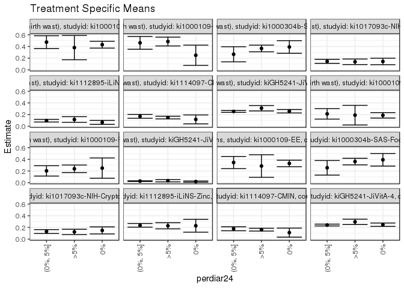

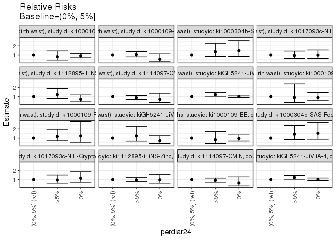

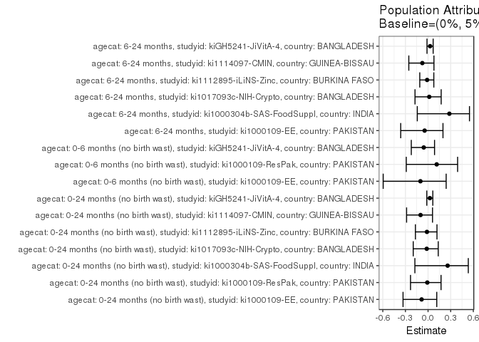

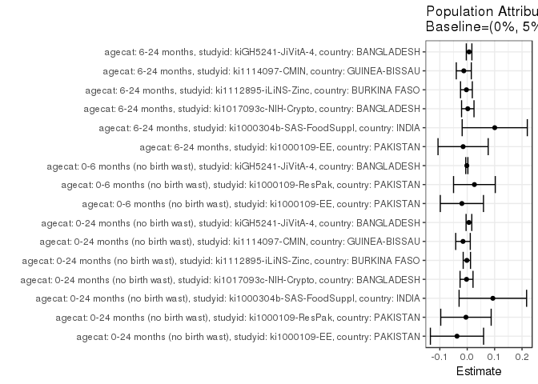

## Results Table

### Parameter: TSM

| agecat | studyid | country | intervention_level | baseline_level | estimate | ci_lower | ci_upper |
| --- | --- | --- | --- | --- | --- | --- | --- |
| 0-24 months (no birth wast) | ki1000109-EE | PAKISTAN | (0%, 5%] | NA | 0.4750000 | 0.3654263 | 0.5845737 |
| 0-24 months (no birth wast) | ki1000109-EE | PAKISTAN | >5% | NA | 0.3809524 | 0.1729767 | 0.5889281 |
| 0-24 months (no birth wast) | ki1000109-EE | PAKISTAN | 0% | NA | 0.4311594 | 0.3726556 | 0.4896633 |
| 0-24 months (no birth wast) | ki1000109-ResPak | PAKISTAN | (0%, 5%] | NA | 0.4625000 | 0.3530426 | 0.5719574 |
| 0-24 months (no birth wast) | ki1000109-ResPak | PAKISTAN | >5% | NA | 0.4852071 | 0.4097185 | 0.5606957 |
| 0-24 months (no birth wast) | ki1000109-ResPak | PAKISTAN | 0% | NA | 0.2500000 | 0.0764439 | 0.4235561 |
| 0-24 months (no birth wast) | ki1000304b-SAS-FoodSuppl | INDIA | (0%, 5%] | NA | 0.2666667 | 0.1372993 | 0.3960340 |
| 0-24 months (no birth wast) | ki1000304b-SAS-FoodSuppl | INDIA | >5% | NA | 0.3663004 | 0.3090768 | 0.4235239 |
| 0-24 months (no birth wast) | ki1000304b-SAS-FoodSuppl | INDIA | 0% | NA | 0.3924051 | 0.2845957 | 0.5002145 |
| 0-24 months (no birth wast) | ki1017093c-NIH-Crypto | BANGLADESH | (0%, 5%] | NA | 0.1457286 | 0.1110418 | 0.1804155 |
| 0-24 months (no birth wast) | ki1017093c-NIH-Crypto | BANGLADESH | >5% | NA | 0.1379310 | 0.0904642 | 0.1853979 |
| 0-24 months (no birth wast) | ki1017093c-NIH-Crypto | BANGLADESH | 0% | NA | 0.1437908 | 0.0881561 | 0.1994256 |
| 0-24 months (no birth wast) | ki1112895-iLiNS-Zinc | BURKINA FASO | (0%, 5%] | NA | 0.0954274 | 0.0727628 | 0.1180921 |
| 0-24 months (no birth wast) | ki1112895-iLiNS-Zinc | BURKINA FASO | >5% | NA | 0.1158392 | 0.0671484 | 0.1645301 |
| 0-24 months (no birth wast) | ki1112895-iLiNS-Zinc | BURKINA FASO | 0% | NA | 0.0669856 | 0.0327650 | 0.1012063 |
| 0-24 months (no birth wast) | ki1114097-CMIN | GUINEA-BISSAU | (0%, 5%] | NA | 0.1703854 | 0.1371863 | 0.2035845 |
| 0-24 months (no birth wast) | ki1114097-CMIN | GUINEA-BISSAU | >5% | NA | 0.1494505 | 0.1262780 | 0.1726231 |
| 0-24 months (no birth wast) | ki1114097-CMIN | GUINEA-BISSAU | 0% | NA | 0.1176471 | 0.0410428 | 0.1942513 |
| 0-24 months (no birth wast) | kiGH5241-JiVitA-4 | BANGLADESH | (0%, 5%] | NA | 0.2540059 | 0.2380620 | 0.2699499 |
| 0-24 months (no birth wast) | kiGH5241-JiVitA-4 | BANGLADESH | >5% | NA | 0.3091266 | 0.2629917 | 0.3552615 |
| 0-24 months (no birth wast) | kiGH5241-JiVitA-4 | BANGLADESH | 0% | NA | 0.2574872 | 0.2278866 | 0.2870878 |
| 0-6 months (no birth wast) | ki1000109-EE | PAKISTAN | (0%, 5%] | NA | 0.2125000 | 0.1227384 | 0.3022616 |
| 0-6 months (no birth wast) | ki1000109-EE | PAKISTAN | >5% | NA | 0.1904762 | 0.0223031 | 0.3586493 |
| 0-6 months (no birth wast) | ki1000109-EE | PAKISTAN | 0% | NA | 0.1875000 | 0.1410529 | 0.2339471 |
| 0-6 months (no birth wast) | ki1000109-ResPak | PAKISTAN | (0%, 5%] | NA | 0.2025316 | 0.1137465 | 0.2913168 |
| 0-6 months (no birth wast) | ki1000109-ResPak | PAKISTAN | >5% | NA | 0.2380952 | 0.1735711 | 0.3026193 |
| 0-6 months (no birth wast) | ki1000109-ResPak | PAKISTAN | 0% | NA | 0.2500000 | 0.0764415 | 0.4235585 |
| 0-6 months (no birth wast) | kiGH5241-JiVitA-4 | BANGLADESH | (0%, 5%] | NA | 0.0270781 | 0.0214354 | 0.0327208 |
| 0-6 months (no birth wast) | kiGH5241-JiVitA-4 | BANGLADESH | >5% | NA | 0.0334728 | 0.0143742 | 0.0525714 |
| 0-6 months (no birth wast) | kiGH5241-JiVitA-4 | BANGLADESH | 0% | NA | 0.0191865 | 0.0091237 | 0.0292492 |
| 6-24 months | ki1000109-EE | PAKISTAN | (0%, 5%] | NA | 0.3456790 | 0.2419698 | 0.4493882 |
| 6-24 months | ki1000109-EE | PAKISTAN | >5% | NA | 0.2857143 | 0.0922413 | 0.4791872 |
| 6-24 months | ki1000109-EE | PAKISTAN | 0% | NA | 0.3296703 | 0.2738322 | 0.3855084 |
| 6-24 months | ki1000304b-SAS-FoodSuppl | INDIA | (0%, 5%] | NA | 0.2553191 | 0.1305041 | 0.3801342 |
| 6-24 months | ki1000304b-SAS-FoodSuppl | INDIA | >5% | NA | 0.3623188 | 0.3055406 | 0.4190970 |
| 6-24 months | ki1000304b-SAS-FoodSuppl | INDIA | 0% | NA | 0.3924051 | 0.2845974 | 0.5002128 |
| 6-24 months | ki1017093c-NIH-Crypto | BANGLADESH | (0%, 5%] | NA | 0.1294416 | 0.0962725 | 0.1626107 |
| 6-24 months | ki1017093c-NIH-Crypto | BANGLADESH | >5% | NA | 0.1237624 | 0.0783185 | 0.1692062 |
| 6-24 months | ki1017093c-NIH-Crypto | BANGLADESH | 0% | NA | 0.1492537 | 0.0888789 | 0.2096286 |
| 6-24 months | ki1112895-iLiNS-Zinc | BURKINA FASO | (0%, 5%] | NA | 0.2365039 | 0.2054036 | 0.2676041 |
| 6-24 months | ki1112895-iLiNS-Zinc | BURKINA FASO | >5% | NA | 0.2279910 | 0.1757490 | 0.2802330 |
| 6-24 months | ki1112895-iLiNS-Zinc | BURKINA FASO | 0% | NA | 0.2290749 | 0.1190043 | 0.3391454 |
| 6-24 months | ki1114097-CMIN | GUINEA-BISSAU | (0%, 5%] | NA | 0.1776860 | 0.1436200 | 0.2117519 |
| 6-24 months | ki1114097-CMIN | GUINEA-BISSAU | >5% | NA | 0.1622517 | 0.1382365 | 0.1862668 |
| 6-24 months | ki1114097-CMIN | GUINEA-BISSAU | 0% | NA | 0.1111111 | 0.0334811 | 0.1887411 |
| 6-24 months | kiGH5241-JiVitA-4 | BANGLADESH | (0%, 5%] | NA | 0.2412624 | 0.2254744 | 0.2570503 |
| 6-24 months | kiGH5241-JiVitA-4 | BANGLADESH | >5% | NA | 0.2958293 | 0.2500870 | 0.3415716 |
| 6-24 months | kiGH5241-JiVitA-4 | BANGLADESH | 0% | NA | 0.2470803 | 0.2183327 | 0.2758279 |

### Parameter: E(Y)

| agecat | studyid | country | intervention_level | baseline_level | estimate | ci_lower | ci_upper |
| --- | --- | --- | --- | --- | --- | --- | --- |
| 0-24 months (no birth wast) | ki1000109-EE | PAKISTAN | NA | NA | 0.4376658 | 0.3875213 | 0.4878102 |
| 0-24 months (no birth wast) | ki1000109-ResPak | PAKISTAN | NA | NA | 0.4578755 | 0.3986666 | 0.5170843 |
| 0-24 months (no birth wast) | ki1000304b-SAS-FoodSuppl | INDIA | NA | NA | 0.3602015 | 0.3129196 | 0.4074834 |
| 0-24 months (no birth wast) | ki1017093c-NIH-Crypto | BANGLADESH | NA | NA | 0.1432361 | 0.1182149 | 0.1682572 |
| 0-24 months (no birth wast) | ki1112895-iLiNS-Zinc | BURKINA FASO | NA | NA | 0.0940426 | 0.0721067 | 0.1159784 |
| 0-24 months (no birth wast) | ki1114097-CMIN | GUINEA-BISSAU | NA | NA | 0.1549966 | 0.1364963 | 0.1734969 |
| 0-24 months (no birth wast) | kiGH5241-JiVitA-4 | BANGLADESH | NA | NA | 0.2602648 | 0.2465010 | 0.2740287 |
| 0-6 months (no birth wast) | ki1000109-EE | PAKISTAN | NA | NA | 0.1930295 | 0.1529228 | 0.2331362 |
| 0-6 months (no birth wast) | ki1000109-ResPak | PAKISTAN | NA | NA | 0.2287823 | 0.1786790 | 0.2788855 |
| 0-6 months (no birth wast) | kiGH5241-JiVitA-4 | BANGLADESH | NA | NA | 0.0256203 | 0.0209093 | 0.0303314 |
| 6-24 months | ki1000109-EE | PAKISTAN | NA | NA | 0.3306667 | 0.2829875 | 0.3783458 |
| 6-24 months | ki1000304b-SAS-FoodSuppl | INDIA | NA | NA | 0.3557214 | 0.3088651 | 0.4025777 |
| 6-24 months | ki1017093c-NIH-Crypto | BANGLADESH | NA | NA | 0.1315068 | 0.1069744 | 0.1560393 |
| 6-24 months | ki1112895-iLiNS-Zinc | BURKINA FASO | NA | NA | 0.2335915 | 0.1982492 | 0.2689339 |
| 6-24 months | ki1114097-CMIN | GUINEA-BISSAU | NA | NA | 0.1651755 | 0.1460754 | 0.1842756 |
| 6-24 months | kiGH5241-JiVitA-4 | BANGLADESH | NA | NA | 0.2481046 | 0.2344735 | 0.2617358 |

### Parameter: RR

| agecat | studyid | country | intervention_level | baseline_level | estimate | ci_lower | ci_upper |
| --- | --- | --- | --- | --- | --- | --- | --- |
| 0-24 months (no birth wast) | ki1000109-EE | PAKISTAN | (0%, 5%] | (0%, 5%] | 1.0000000 | 1.0000000 | 1.000000 |
| 0-24 months (no birth wast) | ki1000109-EE | PAKISTAN | >5% | (0%, 5%] | 0.8020050 | 0.4433869 | 1.450679 |
| 0-24 months (no birth wast) | ki1000109-EE | PAKISTAN | 0% | (0%, 5%] | 0.9077040 | 0.6945671 | 1.186245 |
| 0-24 months (no birth wast) | ki1000109-ResPak | PAKISTAN | (0%, 5%] | (0%, 5%] | 1.0000000 | 1.0000000 | 1.000000 |
| 0-24 months (no birth wast) | ki1000109-ResPak | PAKISTAN | >5% | (0%, 5%] | 1.0490964 | 0.7903386 | 1.392572 |
| 0-24 months (no birth wast) | ki1000109-ResPak | PAKISTAN | 0% | (0%, 5%] | 0.5405405 | 0.2595926 | 1.125549 |
| 0-24 months (no birth wast) | ki1000304b-SAS-FoodSuppl | INDIA | (0%, 5%] | (0%, 5%] | 1.0000000 | 1.0000000 | 1.000000 |
| 0-24 months (no birth wast) | ki1000304b-SAS-FoodSuppl | INDIA | >5% | (0%, 5%] | 1.3736264 | 0.8251370 | 2.286710 |
| 0-24 months (no birth wast) | ki1000304b-SAS-FoodSuppl | INDIA | 0% | (0%, 5%] | 1.4715190 | 0.8426305 | 2.569772 |
| 0-24 months (no birth wast) | ki1017093c-NIH-Crypto | BANGLADESH | (0%, 5%] | (0%, 5%] | 1.0000000 | 1.0000000 | 1.000000 |
| 0-24 months (no birth wast) | ki1017093c-NIH-Crypto | BANGLADESH | >5% | (0%, 5%] | 0.9464923 | 0.6228667 | 1.438265 |
| 0-24 months (no birth wast) | ki1017093c-NIH-Crypto | BANGLADESH | 0% | (0%, 5%] | 0.9867027 | 0.6264709 | 1.554074 |
| 0-24 months (no birth wast) | ki1112895-iLiNS-Zinc | BURKINA FASO | (0%, 5%] | (0%, 5%] | 1.0000000 | 1.0000000 | 1.000000 |
| 0-24 months (no birth wast) | ki1112895-iLiNS-Zinc | BURKINA FASO | >5% | (0%, 5%] | 1.2138987 | 0.7857286 | 1.875393 |
| 0-24 months (no birth wast) | ki1112895-iLiNS-Zinc | BURKINA FASO | 0% | (0%, 5%] | 0.7019537 | 0.4176795 | 1.179706 |
| 0-24 months (no birth wast) | ki1114097-CMIN | GUINEA-BISSAU | (0%, 5%] | (0%, 5%] | 1.0000000 | 1.0000000 | 1.000000 |
| 0-24 months (no birth wast) | ki1114097-CMIN | GUINEA-BISSAU | >5% | (0%, 5%] | 0.8771324 | 0.6837874 | 1.125147 |
| 0-24 months (no birth wast) | ki1114097-CMIN | GUINEA-BISSAU | 0% | (0%, 5%] | 0.6904762 | 0.3499243 | 1.362459 |
| 0-24 months (no birth wast) | kiGH5241-JiVitA-4 | BANGLADESH | (0%, 5%] | (0%, 5%] | 1.0000000 | 1.0000000 | 1.000000 |
| 0-24 months (no birth wast) | kiGH5241-JiVitA-4 | BANGLADESH | >5% | (0%, 5%] | 1.2170054 | 1.0384413 | 1.426274 |
| 0-24 months (no birth wast) | kiGH5241-JiVitA-4 | BANGLADESH | 0% | (0%, 5%] | 1.0137055 | 0.8893209 | 1.155487 |
| 0-6 months (no birth wast) | ki1000109-EE | PAKISTAN | (0%, 5%] | (0%, 5%] | 1.0000000 | 1.0000000 | 1.000000 |
| 0-6 months (no birth wast) | ki1000109-EE | PAKISTAN | >5% | (0%, 5%] | 0.8963585 | 0.3368333 | 2.385330 |
| 0-6 months (no birth wast) | ki1000109-EE | PAKISTAN | 0% | (0%, 5%] | 0.8823529 | 0.5407224 | 1.439827 |
| 0-6 months (no birth wast) | ki1000109-ResPak | PAKISTAN | (0%, 5%] | (0%, 5%] | 1.0000000 | 1.0000000 | 1.000000 |
| 0-6 months (no birth wast) | ki1000109-ResPak | PAKISTAN | >5% | (0%, 5%] | 1.1755952 | 0.7021524 | 1.968268 |
| 0-6 months (no birth wast) | ki1000109-ResPak | PAKISTAN | 0% | (0%, 5%] | 1.2343750 | 0.5430833 | 2.805613 |
| 0-6 months (no birth wast) | kiGH5241-JiVitA-4 | BANGLADESH | (0%, 5%] | (0%, 5%] | 1.0000000 | 1.0000000 | 1.000000 |
| 0-6 months (no birth wast) | kiGH5241-JiVitA-4 | BANGLADESH | >5% | (0%, 5%] | 1.2361584 | 0.6678504 | 2.288069 |
| 0-6 months (no birth wast) | kiGH5241-JiVitA-4 | BANGLADESH | 0% | (0%, 5%] | 0.7085616 | 0.4002165 | 1.254470 |
| 6-24 months | ki1000109-EE | PAKISTAN | (0%, 5%] | (0%, 5%] | 1.0000000 | 1.0000000 | 1.000000 |
| 6-24 months | ki1000109-EE | PAKISTAN | >5% | (0%, 5%] | 0.8265306 | 0.3940966 | 1.733465 |
| 6-24 months | ki1000109-EE | PAKISTAN | 0% | (0%, 5%] | 0.9536892 | 0.6757428 | 1.345960 |
| 6-24 months | ki1000304b-SAS-FoodSuppl | INDIA | (0%, 5%] | (0%, 5%] | 1.0000000 | 1.0000000 | 1.000000 |
| 6-24 months | ki1000304b-SAS-FoodSuppl | INDIA | >5% | (0%, 5%] | 1.4190821 | 0.8492927 | 2.371143 |
| 6-24 months | ki1000304b-SAS-FoodSuppl | INDIA | 0% | (0%, 5%] | 1.5369198 | 0.8772271 | 2.692715 |
| 6-24 months | ki1017093c-NIH-Crypto | BANGLADESH | (0%, 5%] | (0%, 5%] | 1.0000000 | 1.0000000 | 1.000000 |
| 6-24 months | ki1017093c-NIH-Crypto | BANGLADESH | >5% | (0%, 5%] | 0.9561250 | 0.6110196 | 1.496147 |
| 6-24 months | ki1017093c-NIH-Crypto | BANGLADESH | 0% | (0%, 5%] | 1.1530582 | 0.7143181 | 1.861276 |
| 6-24 months | ki1112895-iLiNS-Zinc | BURKINA FASO | (0%, 5%] | (0%, 5%] | 1.0000000 | 1.0000000 | 1.000000 |
| 6-24 months | ki1112895-iLiNS-Zinc | BURKINA FASO | >5% | (0%, 5%] | 0.9640053 | 0.7688619 | 1.208678 |
| 6-24 months | ki1112895-iLiNS-Zinc | BURKINA FASO | 0% | (0%, 5%] | 0.9685884 | 0.6103823 | 1.537010 |
| 6-24 months | ki1114097-CMIN | GUINEA-BISSAU | (0%, 5%] | (0%, 5%] | 1.0000000 | 1.0000000 | 1.000000 |
| 6-24 months | ki1114097-CMIN | GUINEA-BISSAU | >5% | (0%, 5%] | 0.9131372 | 0.7167161 | 1.163389 |
| 6-24 months | ki1114097-CMIN | GUINEA-BISSAU | 0% | (0%, 5%] | 0.6253230 | 0.3030115 | 1.290475 |
| 6-24 months | kiGH5241-JiVitA-4 | BANGLADESH | (0%, 5%] | (0%, 5%] | 1.0000000 | 1.0000000 | 1.000000 |
| 6-24 months | kiGH5241-JiVitA-4 | BANGLADESH | >5% | (0%, 5%] | 1.2261726 | 1.0418716 | 1.443075 |
| 6-24 months | kiGH5241-JiVitA-4 | BANGLADESH | 0% | (0%, 5%] | 1.0241146 | 0.8960877 | 1.170433 |

### Parameter: PAR

| agecat | studyid | country | intervention_level | baseline_level | estimate | ci_lower | ci_upper |
| --- | --- | --- | --- | --- | --- | --- | --- |
| 0-24 months (no birth wast) | ki1000109-EE | PAKISTAN | (0%, 5%] | NA | -0.0373342 | -0.1344182 | 0.0597498 |
| 0-24 months (no birth wast) | ki1000109-ResPak | PAKISTAN | (0%, 5%] | NA | -0.0046245 | -0.0966290 | 0.0873800 |
| 0-24 months (no birth wast) | ki1000304b-SAS-FoodSuppl | INDIA | (0%, 5%] | NA | 0.0935348 | -0.0296619 | 0.2167316 |
| 0-24 months (no birth wast) | ki1017093c-NIH-Crypto | BANGLADESH | (0%, 5%] | NA | -0.0024926 | -0.0261365 | 0.0211514 |
| 0-24 months (no birth wast) | ki1112895-iLiNS-Zinc | BURKINA FASO | (0%, 5%] | NA | -0.0013849 | -0.0147021 | 0.0119324 |
| 0-24 months (no birth wast) | ki1114097-CMIN | GUINEA-BISSAU | (0%, 5%] | NA | -0.0153888 | -0.0419531 | 0.0111755 |
| 0-24 months (no birth wast) | kiGH5241-JiVitA-4 | BANGLADESH | (0%, 5%] | NA | 0.0062589 | -0.0041770 | 0.0166948 |
| 0-6 months (no birth wast) | ki1000109-EE | PAKISTAN | (0%, 5%] | NA | -0.0194705 | -0.0982712 | 0.0593302 |
| 0-6 months (no birth wast) | ki1000109-ResPak | PAKISTAN | (0%, 5%] | NA | 0.0262506 | -0.0498891 | 0.1023904 |
| 0-6 months (no birth wast) | kiGH5241-JiVitA-4 | BANGLADESH | (0%, 5%] | NA | -0.0014578 | -0.0053452 | 0.0024297 |
| 6-24 months | ki1000109-EE | PAKISTAN | (0%, 5%] | NA | -0.0150123 | -0.1065683 | 0.0765436 |
| 6-24 months | ki1000304b-SAS-FoodSuppl | INDIA | (0%, 5%] | NA | 0.1004022 | -0.0184737 | 0.2192782 |
| 6-24 months | ki1017093c-NIH-Crypto | BANGLADESH | (0%, 5%] | NA | 0.0020652 | -0.0206158 | 0.0247463 |
| 6-24 months | ki1112895-iLiNS-Zinc | BURKINA FASO | (0%, 5%] | NA | -0.0029123 | -0.0243985 | 0.0185738 |
| 6-24 months | ki1114097-CMIN | GUINEA-BISSAU | (0%, 5%] | NA | -0.0125105 | -0.0399363 | 0.0149154 |
| 6-24 months | kiGH5241-JiVitA-4 | BANGLADESH | (0%, 5%] | NA | 0.0068423 | -0.0033186 | 0.0170031 |

### Parameter: PAF

| agecat | studyid | country | intervention_level | baseline_level | estimate | ci_lower | ci_upper |
| --- | --- | --- | --- | --- | --- | --- | --- |
| 0-24 months (no birth wast) | ki1000109-EE | PAKISTAN | (0%, 5%] | NA | -0.0853030 | -0.3316028 | 0.1154400 |
| 0-24 months (no birth wast) | ki1000109-ResPak | PAKISTAN | (0%, 5%] | NA | -0.0101000 | -0.2324215 | 0.1721160 |
| 0-24 months (no birth wast) | ki1000304b-SAS-FoodSuppl | INDIA | (0%, 5%] | NA | 0.2596737 | -0.1746166 | 0.5333941 |
| 0-24 months (no birth wast) | ki1017093c-NIH-Crypto | BANGLADESH | (0%, 5%] | NA | -0.0174018 | -0.1965957 | 0.1349572 |
| 0-24 months (no birth wast) | ki1112895-iLiNS-Zinc | BURKINA FASO | (0%, 5%] | NA | -0.0147261 | -0.1677161 | 0.1182197 |
| 0-24 months (no birth wast) | ki1114097-CMIN | GUINEA-BISSAU | (0%, 5%] | NA | -0.0992847 | -0.2844674 | 0.0592000 |
| 0-24 months (no birth wast) | kiGH5241-JiVitA-4 | BANGLADESH | (0%, 5%] | NA | 0.0240482 | -0.0167011 | 0.0631643 |
| 0-6 months (no birth wast) | ki1000109-EE | PAKISTAN | (0%, 5%] | NA | -0.1008681 | -0.5947141 | 0.2400453 |
| 0-6 months (no birth wast) | ki1000109-ResPak | PAKISTAN | (0%, 5%] | NA | 0.1147407 | -0.2885999 | 0.3918329 |
| 0-6 months (no birth wast) | kiGH5241-JiVitA-4 | BANGLADESH | (0%, 5%] | NA | -0.0568982 | -0.2222713 | 0.0861000 |
| 6-24 months | ki1000109-EE | PAKISTAN | (0%, 5%] | NA | -0.0454002 | -0.3624171 | 0.1978509 |
| 6-24 months | ki1000304b-SAS-FoodSuppl | INDIA | (0%, 5%] | NA | 0.2822497 | -0.1426681 | 0.5491556 |
| 6-24 months | ki1017093c-NIH-Crypto | BANGLADESH | (0%, 5%] | NA | 0.0157043 | -0.1727785 | 0.1738952 |
| 6-24 months | ki1112895-iLiNS-Zinc | BURKINA FASO | (0%, 5%] | NA | -0.0124676 | -0.1097846 | 0.0763156 |
| 6-24 months | ki1114097-CMIN | GUINEA-BISSAU | (0%, 5%] | NA | -0.0757404 | -0.2551256 | 0.0780068 |
| 6-24 months | kiGH5241-JiVitA-4 | BANGLADESH | (0%, 5%] | NA | 0.0275782 | -0.0140521 | 0.0674994 |